# Exploring Indian Weather Patterns: Insights from Data

Jeffrey Asubonteng

2023-11-27

### Introduction

This report focuses on exploring Indian weather dataset. This dataset can be found on Kaggle website. It is about 7MB, consisting of 28448 observations and 42 variables, some of which include temperature, humidity, region, etc. The goal of this project is to apply what I have learnt in my datascience class to explore the dataset. In this report, I apply Principal Component Analysis, t-SNE, clustering, supervised learning, and data visualization on the dataset. With these statistical method mentioned, I apply them on some selected variables.

```r
library(readr)
IndianWeatherRepository <- read_csv("./source_data/IndianWeatherRepository.csv")
IndianWeather <- IndianWeatherRepository
```

### Data Overview and Analysis

- Temperature trends over time

Temperature variable in the dataset are in both celsius and farenheit so I chose the temperature-celsius variable against the last time the dataset was updated. From the figure, the teperature was well distributed.

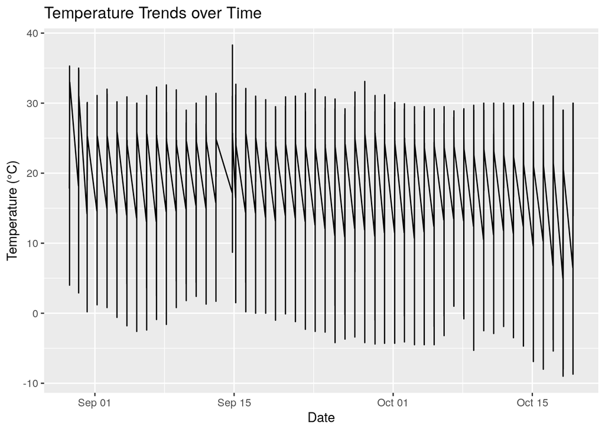

```r
library(ggplot2)

ggplot(IndianWeather, aes(x = last_updated, y = temperature_celsius)) +
  geom_line() +
  labs(title = "Temperature Trends over Time", x = "Date", y = "Temperature (°C)")
```

- Distribution of weather conditions

Among the observations, there are different weather conditions in the dataset so I considered to visualize the counts. From the count, it is observed that India has more clear weather condition compared to the others.

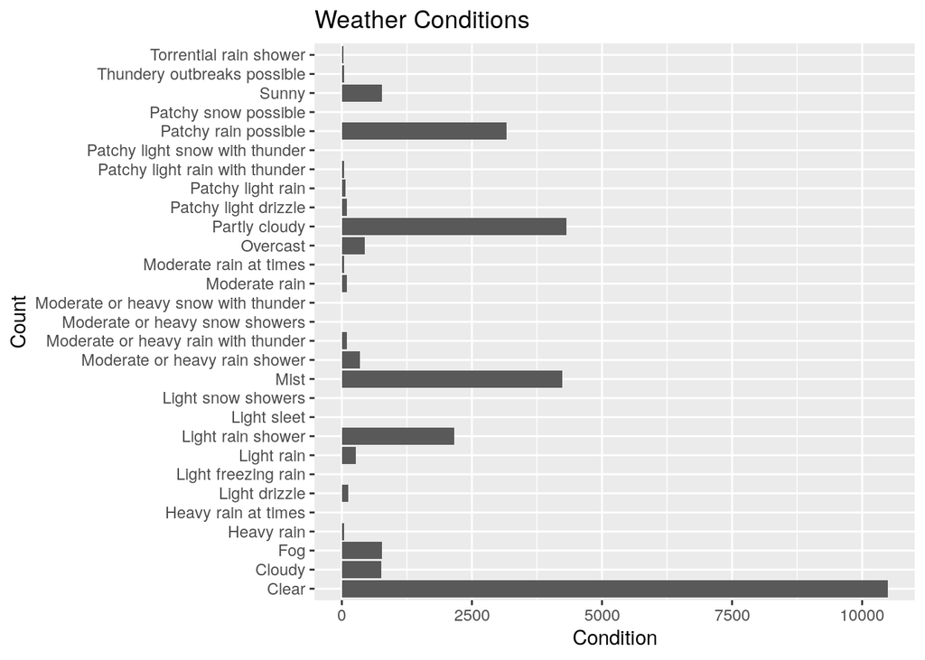

```r
# Weather Conditions
library(ggplot2)
ggplot(IndianWeather, aes(x = condition_text)) +
  geom_bar() +
  coord_flip() +
  labs(title = "Weather Conditions", x = "Count", y = "Condition")
```

- Geographic temperature variation

I delve into the analysis of temperature variations across locations in India. Utilizing statistical visualization I aim to elucidate the spatial distribution of temperatures throughout the country. The code below constructs a geographical scatter plot depicting temperature fluctuations across longitude and latitude coordinates in India. The visualization represents temperature values as a color gradient, allowing for an intuitive comprehension of temperature disparities across various geographical regions.

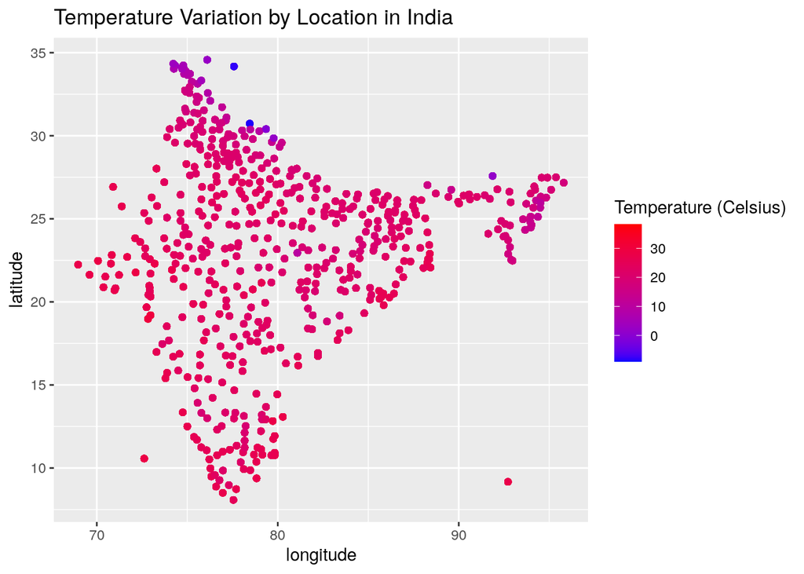

```r
library(ggplot2)
ggplot(data = IndianWeather, aes(x = longitude, y = latitude, color = temperature_celsius)) +
  geom_point() +
  scale_color_gradient(low = "blue", high = "red", name = "Temperature (Celsius)") +
  labs(title = "Temperature Variation by Location in India")
```

- Other multivariate analysis using PCA and clustering techniques

```r
selected_variables <- IndianWeather[, c("temperature_celsius", "humidity", "wind_mph")]
scaled_data <- scale(selected_variables)

pca_result <- princomp(scaled_data)
# View the loadings for the first two principal components
loadings(pca_result)[, 1:2]
```

```
##                         Comp.1     Comp.2
## temperature_celsius  0.6942673 0.07792352
## humidity            -0.2841993 0.94301565
## wind_mph             0.6612289 0.32349561
```

```r
# Extract PC scores
pc_scores <- pca_result$scores


# Clustering
num_clusters <- 3
kmeans_result <- kmeans(scaled_data, centers = num_clusters)

cluster_assignments <- kmeans_result$cluster
table(cluster_assignments)
```

```
## cluster_assignments
##     1     2     3
##  7771 15831  4846
```

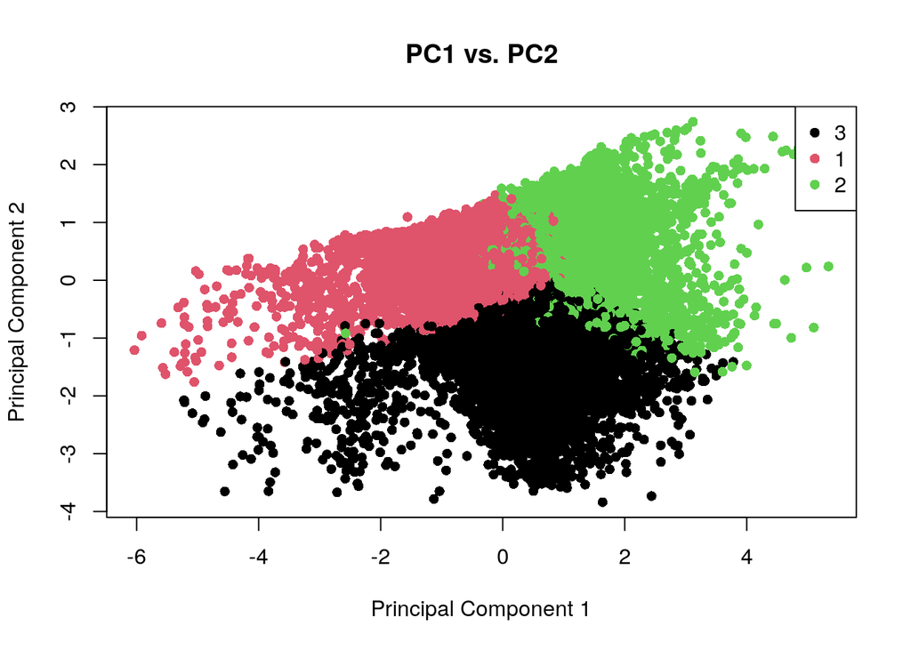

```r
# Assuming PC1 and PC2 are the first two principal components
plot(pc_scores[, 1], pc_scores[, 2],
     col = cluster_assignments, pch = 16,
     xlab = "Principal Component 1", ylab = "Principal Component 2",
     main = "PC1 vs. PC2")
legend("topright", legend = unique(cluster_assignments), col = 1:length(unique(cluster_assignments)), pch = 16)
```

- Correlation Analysis

To better understand the relationships between wind speed, humidity, and sunrise, correlation coefficients were computed. The correlation table reveals the strength and direction of associations between these variables.

```r
relevant_data <- IndianWeather[, c("wind_mph", "humidity", "sunrise")]

# Convert time of sunrise to numeric format (e.g., minutes since midnight)
relevant_data$sunrise_numeric <- as.numeric(relevant_data$sunrise)
# Selecting relevant columns for correlation
relevant_columns <- relevant_data[c("wind_mph", "humidity", "sunrise_numeric")]

# Calculating correlation matrix
correlation_matrix <- cor(relevant_columns)

correlation_matrix
```

```
##                    wind_mph    humidity sunrise_numeric
## wind_mph         1.00000000 -0.01813135        0.247022
## humidity        -0.01813135  1.00000000       -0.423457
## sunrise_numeric  0.24702198 -0.42345699        1.000000
```

- Heatmap Visualization.

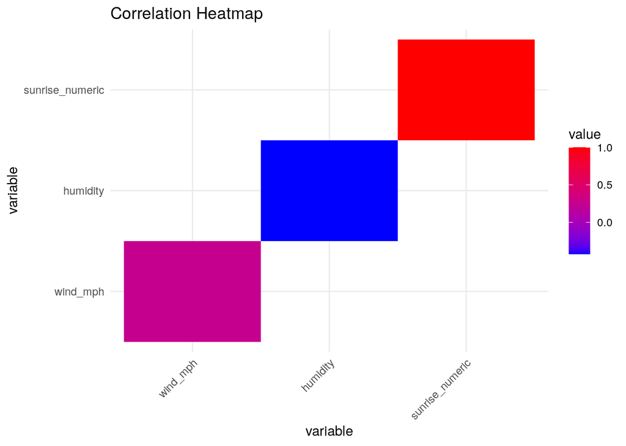

```r
library(ggplot2)
library(reshape2)
correlation_matrix <- data.frame(
  wind_mph = c(1.00000000, -0.01813135, 0.24702198),
  humidity = c(-0.01813135, 1.00000000, -0.42345699),
  sunrise_numeric = c(0.247022, -0.423457, 1.000000)
)

# Redefine the melted matrix with variable names specified
melted_matrix <- melt(correlation_matrix)
ggplot(melted_matrix, aes(x = variable, y = variable, fill = value)) +
  geom_tile() +
  scale_fill_gradient(low = "blue", high = "red") +
  labs(title = "Correlation Heatmap") +
  theme_minimal() +
  theme(axis.text.x = element_text(angle = 45, hjust = 1))
```

- PCA and t-SNE analysis

Principal Component Analysis and t-distributed Stochastic Neighbor Embedding were conducted on the selected variables. The results, visually represent, reveal the underlying structures and relationships among these variables in reduced dimensions. These visualizations assist in comprehending complex interrelationships among the variables, offering insights into their mutual associations and potential patterns.

```r
library(dplyr)
IndianWeather_subset <- IndianWeather %>%
  mutate(sunrise_seconds = as.numeric(IndianWeather$sunrise)) %>%
  select(wind_mph, humidity, sunrise_seconds)

# Assuming 'IndianWeather_subset' contains your data
pca_result1 <- prcomp(IndianWeather_subset, scale. = TRUE)
summary(pca_result1)
```

```
## Importance of components:
##                           PC1    PC2    PC3
## Standard deviation     1.2240 0.9921 0.7194
## Proportion of Variance 0.4994 0.3281 0.1725
## Cumulative Proportion  0.4994 0.8275 1.0000
```

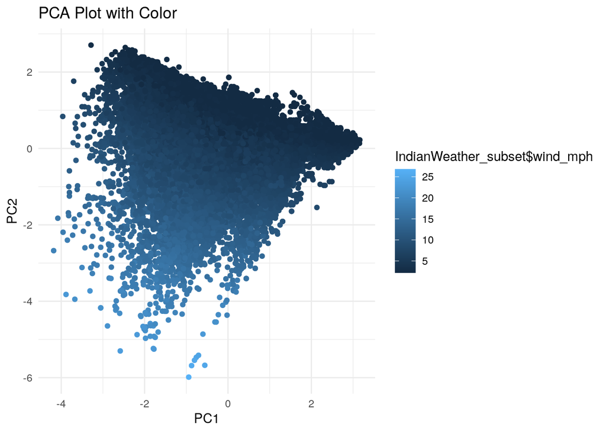

```r
library(ggplot2)
# Convert PCA result to a data frame
pca_df <- as.data.frame(pca_result1$x[, 1:2])  # Considering the first two principal components
ggplot(pca_df, aes(x = PC1, y = PC2, color = IndianWeather_subset$wind_mph)) +
  geom_point() +
  labs(title = "PCA Plot with Color") +
  theme_minimal()
```

```r
# TSNE

library(Rtsne)

IndianWeather_unique <- unique(IndianWeather_subset)

tsne_result <- Rtsne(IndianWeather_unique, dims = 2, perplexity = 30, verbose = TRUE)
```

```
## Performing PCA
## Read the 20988 x 3 data matrix successfully!
## OpenMP is working. 1 threads.
## Using no_dims = 2, perplexity = 30.000000, and theta = 0.500000
## Computing input similarities...
## Building tree...
##  - point 10000 of 20988
##  - point 20000 of 20988
## Done in 0.84 seconds (sparsity = 0.005022)!
## Learning embedding...
## Iteration 50: error is 107.742550 (50 iterations in 2.10 seconds)
## Iteration 100: error is 95.746853 (50 iterations in 2.51 seconds)
## Iteration 150: error is 79.278018 (50 iterations in 2.25 seconds)
## Iteration 200: error is 73.268754 (50 iterations in 2.23 seconds)
## Iteration 250: error is 69.790627 (50 iterations in 2.26 seconds)
## Iteration 300: error is 2.789227 (50 iterations in 2.26 seconds)
## Iteration 350: error is 2.397951 (50 iterations in 2.20 seconds)
## Iteration 400: error is 2.108156 (50 iterations in 2.24 seconds)
## Iteration 450: error is 1.885683 (50 iterations in 2.18 seconds)
## Iteration 500: error is 1.708034 (50 iterations in 2.19 seconds)
## Iteration 550: error is 1.563547 (50 iterations in 2.21 seconds)
## Iteration 600: error is 1.444623 (50 iterations in 2.15 seconds)
## Iteration 650: error is 1.345273 (50 iterations in 2.15 seconds)
## Iteration 700: error is 1.260675 (50 iterations in 2.16 seconds)
## Iteration 750: error is 1.187655 (50 iterations in 2.17 seconds)
## Iteration 800: error is 1.124917 (50 iterations in 2.17 seconds)
## Iteration 850: error is 1.070220 (50 iterations in 2.15 seconds)
## Iteration 900: error is 1.022859 (50 iterations in 2.15 seconds)
## Iteration 950: error is 0.982605 (50 iterations in 2.17 seconds)
## Iteration 1000: error is 0.947872 (50 iterations in 2.18 seconds)
## Fitting performed in 44.10 seconds.
```

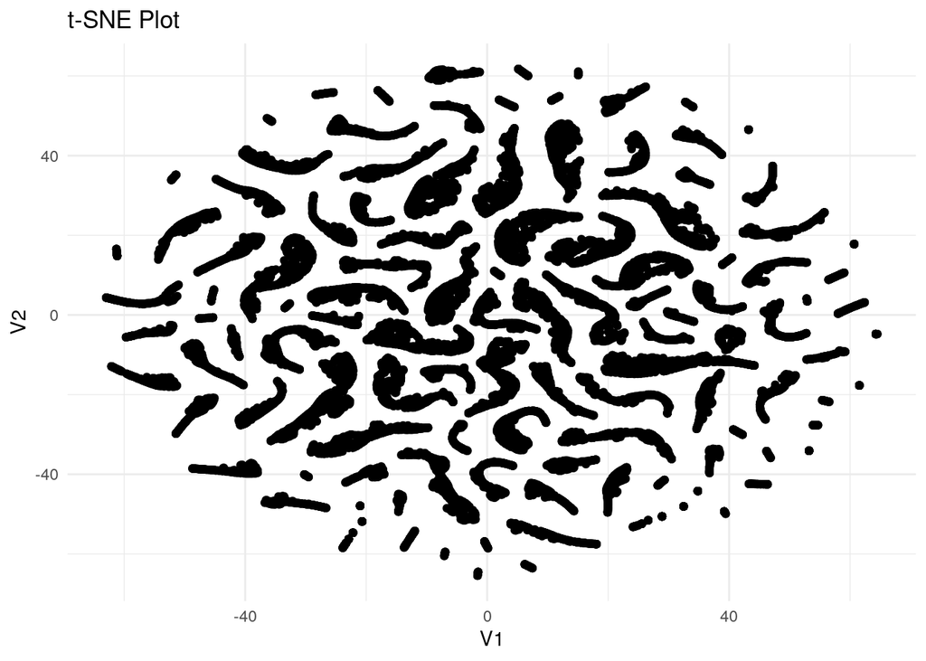

```r
tsne_df <- as.data.frame(tsne_result$Y)

ggplot(tsne_df, aes(x = V1, y = V2)) +
  geom_point() +
  labs(title = "t-SNE Plot") +
  theme_minimal()
```

- Supervised Learning

I delved into supervised learning, employing random forest model to predict tempeature from the dataset. After splitting the data into training and testing set, I trained the model using root mean squared error. Below is the code and plot generated from the model.

```r
X <- IndianWeather_subset
y <- IndianWeather$temperature_celsius  # Target variable

#Train-Test split

library(caret)
set.seed(123)  # For reproducibility
trainIndex <- createDataPartition(y, p = 0.7, list = FALSE)
X_train <- X[trainIndex, ]
X_test <- X[-trainIndex, ]
y_train <- y[trainIndex]
y_test <- y[-trainIndex]

# Model selection and training
library(randomForest)
model <- randomForest(y_train ~ ., data = X_train)

# Prediction
predictions <- predict(model, newdata = X_test)


library(Metrics)
```

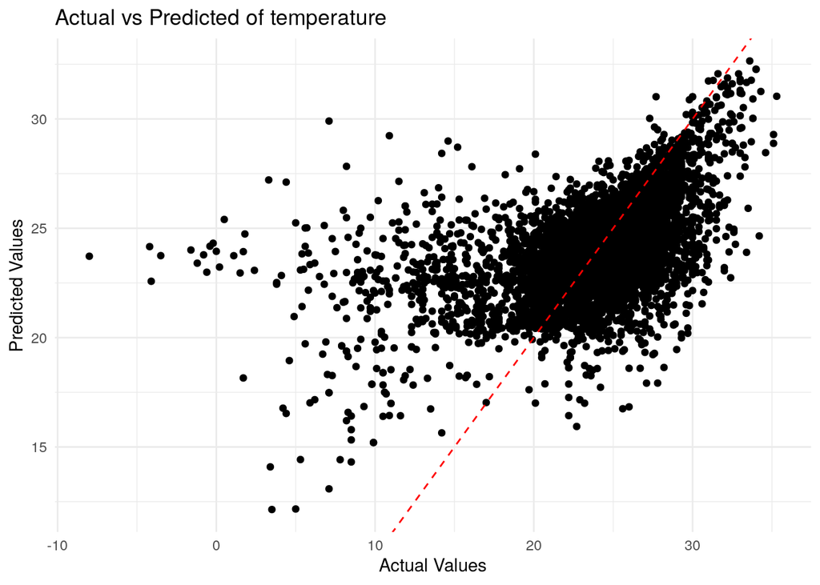

```r
rmse_value <- rmse(predictions, y_test)

# Visualization

library(ggplot2)

# Create a data frame with actual and predicted values
data <- data.frame(Actual = y_test, Predicted = predictions)

# Plotting actual vs predicted values
ggplot(data, aes(x = Actual, y = Predicted)) +
  geom_point() +
  geom_abline(intercept = 0, slope = 1, color = "red", linetype = "dashed") +  # Adding a diagonal line for reference
  labs(title = "Actual vs Predicted of temperature", x = "Actual Values", y = "Predicted Values") +
  theme_minimal()
```

### Conclusion

This dataset contains a lot of variables which are meaningful but I chose to focused on few variables like temperature, humidity, sunrise and others. I have not found anything interesting so far except for the t-SNE analysis which I don’t understand how it generated the figure, but as time goes on in my analysis I hope to achieve something educative.